# Does it work? Comparing predicted and observed accuracy and response times

Florian Sense

March 2018 – last compiled: 2018-07-18 17:20:30

# Goal

We are interested here in getting an idea of how well the model is able to predict the observed behavior/responses. There are two relevant outcome meaures: Accuracy and response times (RT). The predictions for both are a direct consequence of the estimated activation of a given fact at that point in time: If the activation is below a certain threshold, the prediction is that a learner is not able to retrieve the fact accurately anymore; the activation has decayed too much and the fact has been forgotten. Above the threshold, the fact should be retrievable but the probability of a correct retrieval is a function of the activation such that higher activation results in higher probabilites. Furthermore, a fact’s activation can also be translated into an expected response latency. Thus, the latent concept *activation* is directly linked to two observable behavioral measures that provide a proxy to test how well the predicted performance measures match the observed behavior.

# The data

```r
library(BayesFactor)
```

```r
library(ggplot2)
theme_set(theme_minimal())
library(hexbin) # for stat_hexbin()
library(overlapping) # to compute overlap between distributions

load(file.path("..", "data", "cogpsych_data_anon.Rdata"))
figures.folder <- "figures for ICCM poster"


# I'll also check some of these things in the more "controlled" data that we collected in the lab to see what it looks like there.
# I'll download these directly from the OSF. This only needs to be done once and will save the data/CSV to ../data/:
if(FALSE) {
  require("httr")
  path <- file.path("..", "data", "topics_data.csv")
  foo <- GET('https://osf.io/njhz4//?action=download', write_disk(path, overwrite = TRUE))
  lab.data <- read.csv(file.path("..", "data", "topics_data.csv"), row.names=NULL, stringsAsFactors = FALSE)
  # Fix some stuff:
  lab.data$RT <- as.numeric(lab.data$RT)
  lab.data <- subset(lab.data, !is.na(RT))
  lab.data$estRT <- lab.data$estRT * 1000 # make same unit as RT
  write.csv(lab.data, path)
} else {
  lab.data <- read.csv(file.path("..", "data", "topics_data.csv"), row.names=NULL, stringsAsFactors = FALSE)[, -1]
}
```

We are interested here only in the trial-by-trial data recorded during study, which is available in `data`.

# Comparing predicted and observed accuracy

## Binary predictions: Is the activation above/below threshold?

The most simplistic approach is to simply look, for each trial, whether the estimated activation is above or below the retrieval threshold. **The threshold is fixed at -0.8**.

```r
data$est.correct <- data$activation >= -.8
```

```r
(bf.prop <- proportionBF(sum(data$correct == data$est.correct), nrow(data), p=1/2))
```

```
## Bayes factor analysis
## --------------
## [1] Alt., p0=0.5, r=0.5 : 5.763048e+19 ±0%
##
## Against denominator:
##   Null, p = 0.5
## ---
## Bayes factor type: BFproportion, logistic
```

The proportion test yields strong evidence that proportion of instances in which the predicted response matches the observed response is equal not 0.5. It is in fact 0.51. (The statistical test is based on N = 262,978. There’s so much data that this test becomes pretty much meaningless, I think.)

There is a potential problem here, though: The proportion of trials in which the estimated activation is very low is rather high. Ideally, the model will prevent this situation by making sure that items are presented for rehearsal before the activation can decay that much. However, the model can only do this if people are actually studying. It cannot prevent activation to decay between sessions. Therefore, it makes sense to look at the activation of a fact seperately for (a) the first repetition in a session after a delay, and (b) within-session repetitions. The proportion of instances in which the model’s prediction matches the behavior should be higher in (b) and might potentially be very low for (a). In (b), the number of trials in which the predicted activation is below the threshold should ideally be 0.

To summarize these numbers, it’s probably easiest to make a 2x2 table with these numbers:

```r
percent(mean(data$correct & data$est.correct)) # is correct, was predicted correct
```

```
## [1] "43.2%"
```

```r
percent(mean(data$correct & !data$est.correct)) # is correct, was predicted incorrect
```

```
## [1] "47.1%"
```

```r
percent(mean(!data$correct & data$est.correct)) # is not correct, was predicted correct
```

```
## [1] "1.9%"
```

```r
percent(mean(!data$correct & !data$est.correct)) # is not correct, was predicted incorrect
```

```
## [1] "7.8%"
```

These are calculated across all 262,978 observations.

### Between- vs. within-session repetitions

Maarten added the variable `repetition` which indicates how often an item was repeated *within* a session. Thus, all trials on which `repetition == 1` is the first time an item is seen in a session. Consequently, we can look at the activation seperately for trials on which this is TRUE and those on which it is FALSE.

```r
data$first.in.session <- data$repetition == 1

emp.cor <- aggregate(correct ~ first.in.session, data, mean)
est.cor <- aggregate(est.correct ~ first.in.session, data, mean)
```

Since sessions tend to be rather short, the number of trials that are the first repetition of an item in a given session is relatively high: 27.8%. What is interesting is that **in the empirical data**, there is hardly any difference in the proportion of correct responses for the first repetition of an item (88.3%) and for subsequent repetitions (91.0%). **In the estimated responses**, on the other hand, there is a stark difference: 16.2% (first rep) compared to 56.1% (subsequent reps). Notably, both these percentages severely underestimate students’ actual performance.

This indicates that the model doesn’t deal with the way that time elapses between sessions very well. We should look into this in more detail. Now the model just assumes that time “on task” and time “off task” is the same. Some workaround using “psychological time” (as used in ACT-R models) might be a way to handle this. This would require more exploration, though.

### Looking only at the first session

One way to side-step the issue of time between sessions is to look only at the very first session for a moment. Some sessions are very short so lets only look at session that have at least 20 trials and don’t have RTs that are longer than a minute:

```r
data.sess1 <- subset(data, session == 1)

tr <- aggregate(repetition ~ User, data.sess1, length)
tr$maxRT <- aggregate(reactionTime ~ User, data.sess1, max)$reactionTime
tr <- subset(tr, repetition >= 20 & maxRT < (60*1000))

data.sess1 <- subset(data.sess1, User %in% tr$User)
```

Alright, now we have a total of 5128 trials from 65 users. So this is a relatively small subset of the data (read: take this with a grain of salt).

```r
tmp <- subset(data.sess1, !is.infinite(activation)) # this removes the first presentation of an item (i.e., the study trial)
mean(tmp$est.correct) # estimated accuracy
```

```
## [1] 0.4759725
```

```r
mean(tmp$correct) # actual/observed accuracy
```

```
## [1] 0.9224256
```

What we see is that the estimated accuracy in the first session is still rather low when we look only at this subset of the data. This is potentially problematic and we should look into this in more detail.

Remake 2x2 table for comparison:

```r
percent(mean(tmp$correct & tmp$est.correct)) # is correct, was predicted correct
```

```
## [1] "45.9%"
```

```r
percent(mean(tmp$correct & !tmp$est.correct)) # is correct, was predicted incorrect
```

```
## [1] "46.3%"
```

```r
percent(mean(!tmp$correct & tmp$est.correct)) # is not correct, was predicted correct
```

```
## [1] "1.7%"
```

```r
percent(mean(!tmp$correct & !tmp$est.correct)) # is not correct, was predicted incorrect
```

```
## [1] "6.1%"
```

### Predicted vs. observed as a function of repetition

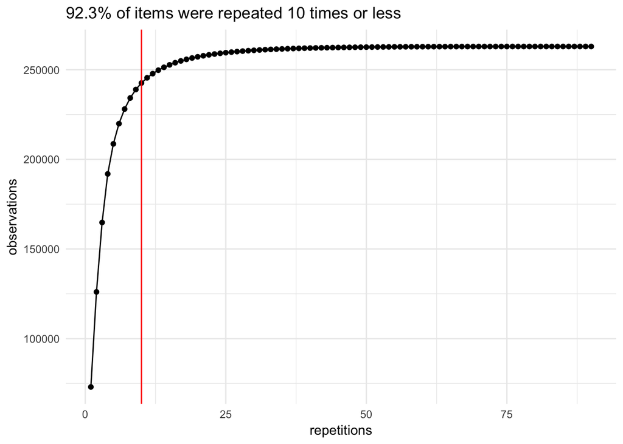

```r
y <- cumsum(table(data$repetition))
a <- data.frame(repetitions=1:length(y), observations=y)
cutoff <- 10
ggplot(a, aes(repetitions, observations)) + geom_line() + geom_point() + geom_vline(xintercept = cutoff, color="red") + labs(title=paste(percent(mean(data$repetition <= cutoff)), "of items were repeated", cutoff, "times or less"))
```

Put together the data we need to make the plot/overview:

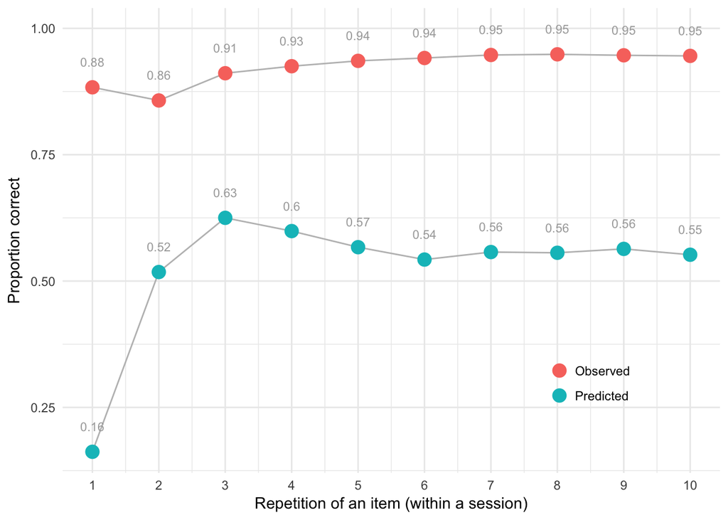

```r
acc.rep <- NULL

for(r in 1:cutoff) {
  tmp <- subset(data, repetition == r)
  acc.rep <- rbind(acc.rep,
                   data.frame(rep=r,
                              type="Observed",
                              correct=mean(tmp$correct)),
                   data.frame(rep=r,
                              type="Predicted",
                              correct=mean(tmp$est.correct))
                   )
}

# Make the plot:
ggplot(acc.rep, aes(x=rep, y=correct, group=type)) +
  geom_line(color="grey") +
  geom_point(aes(color=type), size=4) +
  geom_text(aes(label=round(correct, 2)), nudge_y = .05, size=3, color="darkgray") +
  scale_x_continuous(breaks = seq(1, cutoff, 1)) +
  theme(legend.position = c(0.8, 0.2)) +
  labs(x="Repetition of an item (within a session)", y="Proportion correct", color=NULL) +

  NULL
```

```r
# ggsave(file.path(figures.folder, "Predicted vs. observed accuracy f(rep).pdf"), width = 5, height = 4)
```

### Comparison with TopiCS data

This comparison is not very interesting because the output of the experimental setup did not include the estimated activation on each trial, only the estimated RT. The only comparison we can make is to report that in these data, participants responded correctly on 87.3% of the trials (which is just a little bit lower than the 90.3% in the real world data).

# Comparing predicted and observed response times

The first issue here is that the RTs are very noisy. RTs are notoriously noisy, of course. However, here, we have some extremely long RTs that are probably the result of people just leaving the app running and doing other stuff while the app is patiently waiting for a response to be recorded. So we should first deal with those.

## Dealing with *very* long RTs

```r
range(data$reactionTime, na.rm = TRUE) / 1000 # in seconds
```

```
## [1]     0.002 73100.078
```

```r
RT.cutoff <- c(300, 60*1000) # boundaries in ms
mean(data$reactionTime < RT.cutoff[1], na.rm = TRUE)  # proportion of trials excluded
```

```
## [1] 0.001942311
```

```r
mean(data$reactionTime > RT.cutoff[2], na.rm = TRUE)  # proportion of trials excluded
```

```
## [1] 0.004913371
```

```r
mean(data$reactionTime > RT.cutoff[1] & data$reactionTime < RT.cutoff[2], na.rm = TRUE) # prop. of data retained overall
```

```
## [1] 0.9931403
```

```r
data.RT <- subset(data, reactionTime > RT.cutoff[1] & reactionTime < RT.cutoff[2])
```

## Dealing with RTs that are `NA`

RTs are the time between the prompt appearing on screen and the user pressing the first key to initiate their response. If, however, the user subsequently uses backspace to correct their input, the RT is set to `NA` if the first letter of the input was deleted (but not if other letter are deleted). The logic behind this is that if the user deletes the first letter, they are likely to provide a response that is different from what they had originally intended. This implies that they retrieved one answer but subsequently retrieved another answer that was given instead. Therefore, the RT doesn’t reflect the retrieval time of the given response and is thus not a proxy for the activation of that fact in memory. In that case, we lose the ability to estimate the activation for that particular fact using their RT.

```r
mean(is.na(data$reactionTime))
```

```
## [1] 0.04264996
```

```r
data.RT <- subset(data.RT, !is.na(reactionTime))
```

After removing observations with RTs outside the specified boundaries and those that are `NA`, we are left with 250,035 observations (95.1% of original data).

# Comparing predicted and observed RTs in the subset of “reasonable” RTs

As a first step, lets compare the two RT distributions.

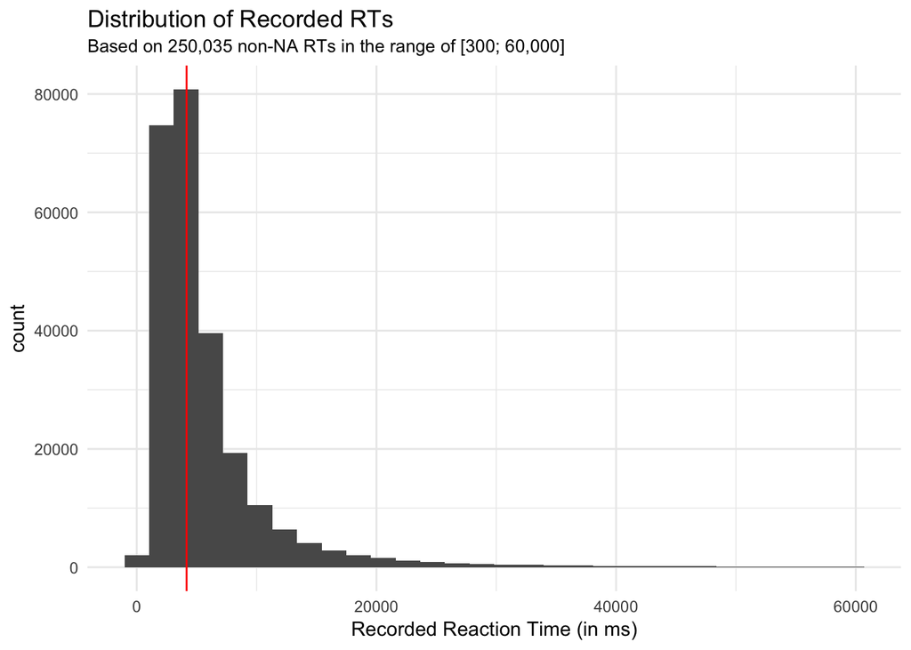

```r
ggplot(data.RT, aes(reactionTime)) +
  geom_histogram() +
  geom_vline(xintercept = median(data.RT$reactionTime), color="red") +
  labs(x="Recorded Reaction Time (in ms)",
       title="Distribution of Recorded RTs",
       subtitle = paste("Based on ", prettify(nrow(data.RT))," non-NA RTs in the range of [", paste(prettyNum(RT.cutoff, big.mark = ","), collapse = "; "), "]", sep=""))
```

```r
mean(is.infinite(data.RT$estimatedResponseTime))
```

```
## [1] 0.1120643
```

```r
mean(data.RT$estimatedResponseTime > RT.cutoff[2])
```

```
## [1] 0.113976
```

```r
mean(!is.infinite(data.RT$estimatedResponseTime) & data.RT$estimatedResponseTime < RT.cutoff[2]) # retained if both are removed
```

```
## [1] 0.886024
```

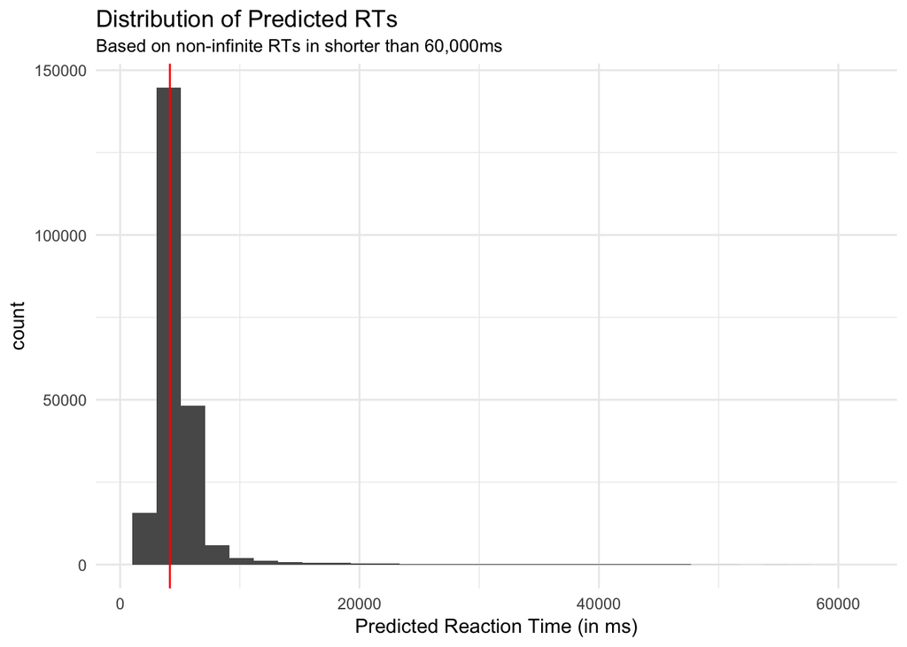

```r
data.RT.sub <- subset(data.RT, !is.infinite(data.RT$estimatedResponseTime) & data.RT$estimatedResponseTime < RT.cutoff[2])

ggplot(data.RT.sub, aes(estimatedResponseTime)) +
  geom_histogram() +
  geom_vline(xintercept = median(data.RT$reactionTime), color="red") +
  labs(x="Predicted Reaction Time (in ms)", title="Distribution of Predicted RTs", subtitle = paste("Based on non-infinite RTs in shorter than ", prettyNum(RT.cutoff[2], big.mark = ","), "ms", sep="")) +
  NULL
```

The distribution looks more narrowly centered around the median with a thinner tail. A more direct comparison might be more interesting:

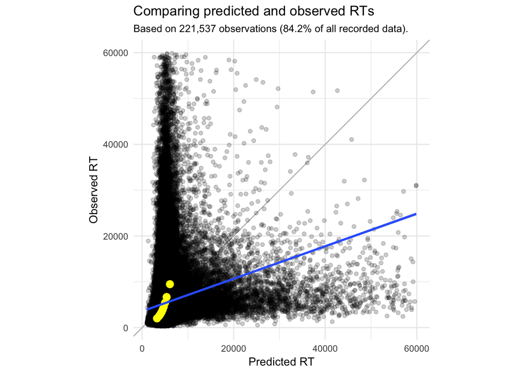

```r
probs <- seq(.1, .9, .1)
quant <- data.frame(estimatedResponseTime = quantile(data.RT.sub$estimatedResponseTime, probs = probs),
                    reactionTime = quantile(data.RT.sub$reactionTime, probs = probs) )

ggplot(data.RT.sub, aes(estimatedResponseTime, reactionTime)) +
  geom_abline(intercept = 0, slope = 1, color="grey") +
  geom_point(alpha=.2) +
  geom_point(data=quant, colour="yellow", size=3) +
  geom_smooth(method="lm") +
  labs(title="Comparing predicted and observed RTs", x="Predicted RT", y="Observed RT",
       subtitle=paste("Based on ", prettyNum(nrow(data.RT.sub), big.mark = ","), " observations (", round((nrow(data.RT.sub)/nrow(data))*100, 1), "% of all recorded data).", sep="")) +
  coord_fixed() +
  NULL
```

For a more digestible plot, this might be nice:

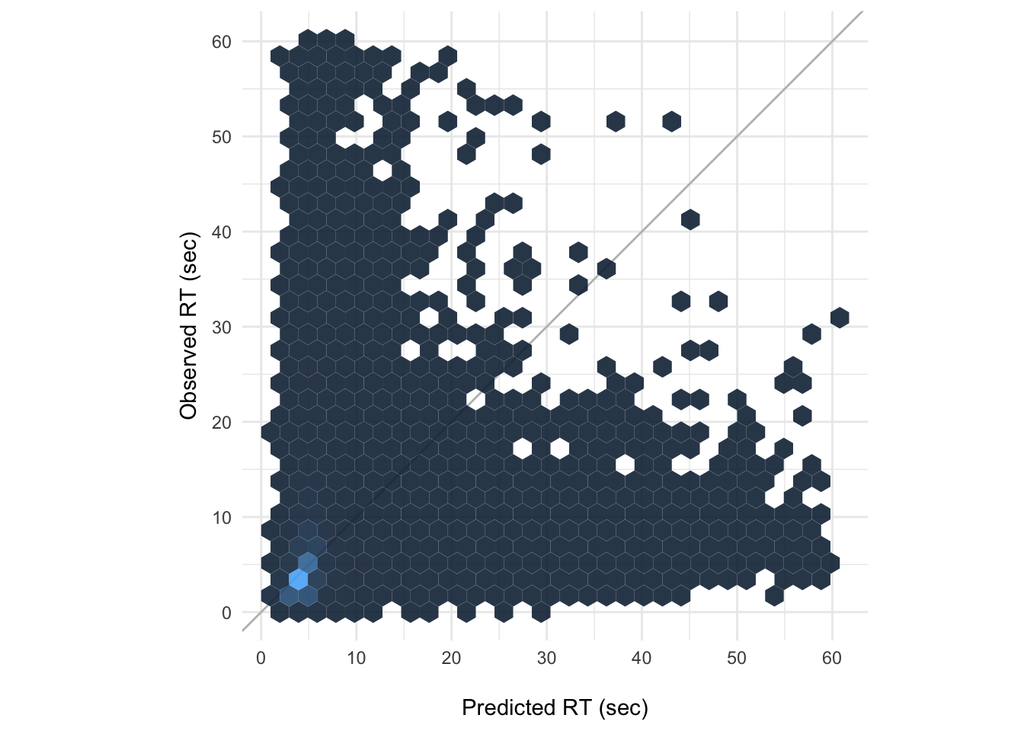

```r
ggplot(data.RT.sub, aes(estimatedResponseTime/1000, reactionTime/1000)) +
  geom_abline(intercept = 0, slope = 1, color="grey") +
  stat_binhex(alpha = .9, show.legend = FALSE) +
  # geom_smooth(method="lm") +
  # labs(title="Comparing predicted and observed RTs", x="\nPredicted RT (ms)", y="\nObserved RT (ms)",
       # subtitle=paste("Based on ", prettyNum(nrow(data.RT.sub), big.mark = ","), " observations (", round((nrow(data.RT.sub)/nrow(data))*100, 1), "% of all recorded data)", sep=""), fill="Observations:") +
  labs(x="\nPredicted RT (sec)", y="\nObserved RT (sec)") +
  coord_fixed() +
  scale_x_continuous(breaks = seq(0, RT.cutoff[2], 10)) +
  scale_y_continuous(breaks = seq(0, RT.cutoff[2], 10)) +
  # theme(legend.title=element_text(size=8)) +
  NULL
```

```r
# ggsave(file.path(figures.folder, "Predicted vs. observed RT distributions hexbin.pdf"), width = 3, height = 3)
```

Another way to approach this might be to plot the distributions in the same figure, to get a direct visual comparison. Here, I will also compute some measures that capture the similarity of the two distributions and overlay them.

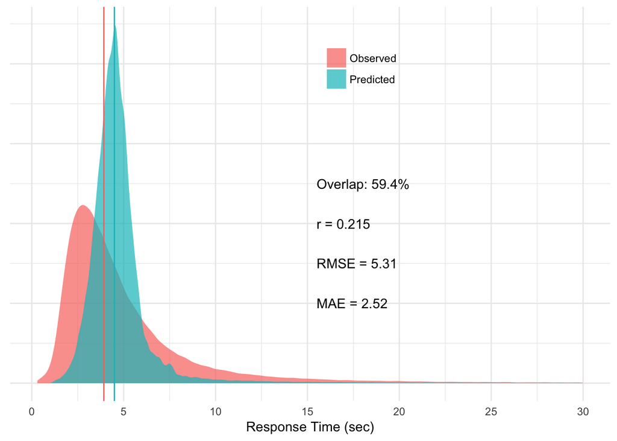

```r
# Compute the overlap between the distributions:
tmp <- list(X1=data.RT.sub$reactionTime, X2=data.RT.sub$estimatedResponseTime)
olap <- overlap(tmp) # compute overlap; percent is stored in $OV

# Correlation between the values?
corr <- cor(data.RT.sub$reactionTime, data.RT.sub$estimatedResponseTime)

## Prepare the plot
# The tail will be very long, so I'll chop some of it off to make the visual presentation a bit nicer:
dist <- rbind(data.frame(x=data.RT.sub$reactionTime, type="Observed"),
              data.frame(x=data.RT.sub$estimatedResponseTime, type="Predicted"))

cutoff <- 30*1000
retained <- mean(dist$x < cutoff)
dist <- subset(dist, x < cutoff)

medians <- aggregate(x ~ type, dist, median)

rmse <- sqrt(mean((data.RT.sub$reactionTime - data.RT.sub$estimatedResponseTime)^2)) / 1000
mae <- mean(abs(data.RT.sub$reactionTime - data.RT.sub$estimatedResponseTime)) / 1000

# Make the plot:
ggplot(dist, aes(x, group=type)) +
  geom_density(aes(fill=type), alpha=.7, color=NA) +
  # Add some text to the plot:
  annotate("text", x=cutoff*.5 + 500, y=2.5/10000, label=paste("Overlap:", percent(olap$OV)), hjust=0) +
  annotate("text", x=cutoff*.5 + 500, y=2/10000, label=paste("r =", round(corr, 3)), hjust=0) +
  annotate("text", x=cutoff*.5 + 500, y=1.5/10000, label=paste("RMSE =", round(rmse, 2)), hjust=0) +
  annotate("text", x=cutoff*.5 + 500, y=1/10000, label=paste("MAE =", round(mae, 2)), hjust=0) +
  geom_vline(data=medians, aes(xintercept=x, color=type), show.legend = FALSE) +
  theme(legend.position = c(0.585, 0.85)) +
  # labs(title="Comparing RT Distributions: Observed vs. Predicted", subtitle="Vertical lines are the distributions' medians", x="Response Time (ms)", y=NULL, fill=NULL) +
  labs(x="Response Time (sec)", y=NULL, fill=NULL) +
  scale_y_continuous(labels = NULL) +
  scale_x_continuous(breaks = seq(0, cutoff, cutoff/6), labels = (seq(0, cutoff, cutoff/6))/1000) +
  NULL
```

```r
# ggsave(file.path(figures.folder, "Predicted vs. observed RT distributions density.pdf"), width = 5, height = 3.5)
```

Using a cutoff of 30,000 for the plotting, we’re retaining 99.4% of the data. Note that the correlation coefficient and the overlap are computed across all data in `data.RT.sub` and are not affected by the `cutoff`.

### Looking only at the first session

Split it up:

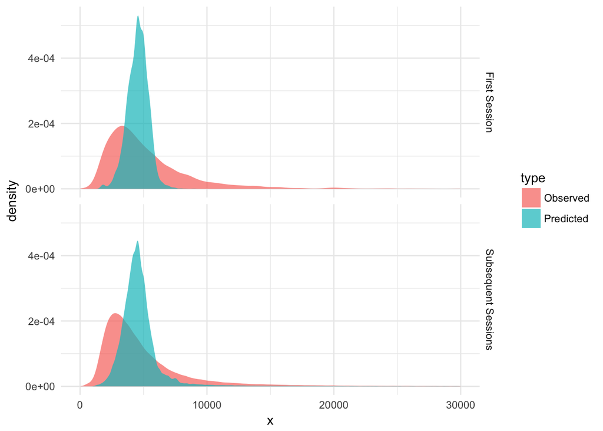

```r
data.RT.sub$sess <- ifelse(data.RT.sub$session == 1, "First Session", "Subsequent Sessions")

dist <- rbind(data.frame(x=data.RT.sub$reactionTime, type="Observed", sess=data.RT.sub$sess),
              data.frame(x=data.RT.sub$estimatedResponseTime, type="Predicted", sess=data.RT.sub$sess))

ggplot(dist, aes(x, group=type)) +
  geom_density(aes(fill=type), alpha=.7, color=NA) +
  facet_grid(sess ~ .) +
  xlim(0, 30*1000)
```

Doesn’t look like there’s much of a difference.

## Conclusions

It’s difficult to get a good feeling for what a reasonable overlap/correlation/RMSE is for the predicted vs. observed RTs. A couple of things that should be noted, though: The RMSE is higher than the median. That seems quite high. The mean absolute error (MAE), on the other hand, is much lower. Which makes sense looking at the hexbin plot above and the correlation coefficient: A lot of values are far off of the predicted values in these noisy data and squaring the errors in the RMSE puts a large penalty on those.

The predicted distribution looks more normal than the observed: Its median is right at its peak, whereas it is shifted to the right of the peak of the observed distribution. RT distributions are usually skewed like that, not normal – might point towards a general problem with predicted RTs that result in a normal distribution?

### Comparision with TopiCS data

I’ll handle the same criteria to subset the data/exclude RTs as above:

```r
mean(is.infinite(lab.data$estRT)) # RT on first encouter is Inf
```

```
## [1] 0.1087378
```

```r
mean(lab.data$RT < RT.cutoff[1])
```

```
## [1] 0.002438831
```

```r
mean(lab.data$RT > RT.cutoff[2]) # Not a single RT is higher than 60s!
```

```
## [1] 0
```

```r
lab.data.RTsub <- subset(lab.data, RT > RT.cutoff[1] & RT < RT.cutoff[2] & !is.infinite(estRT))
```

After subsetting the data for observed RTs within the boundaries of `cutoff` and removing the 10.9% of trials in which the estimated RT is `Inf` (i.e., the first trial of an item), we are retaining 88.9% of the data.

Let have a look:

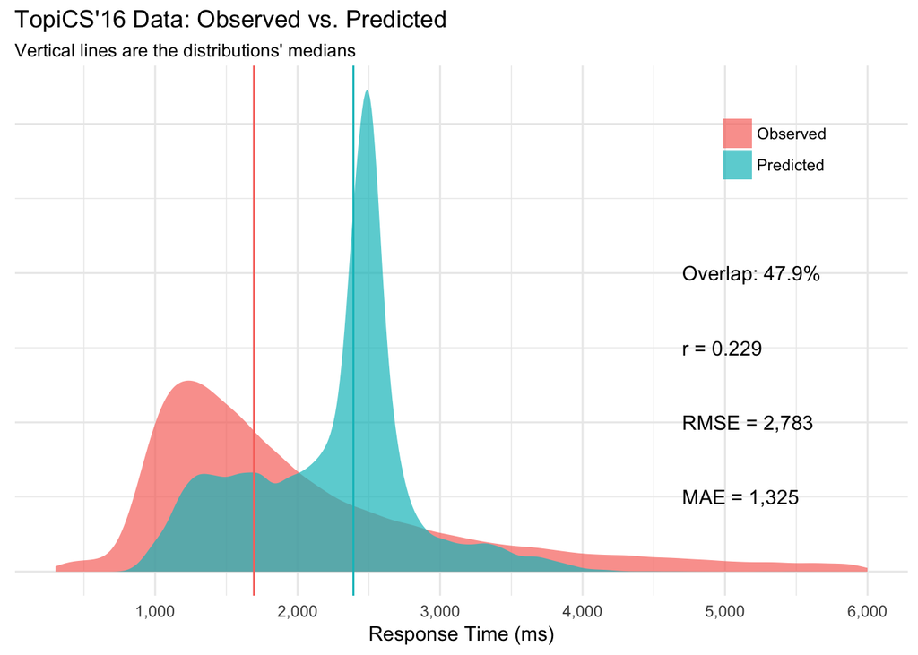

```r
# Compute the overlap between the distributions:
tmp <- list(X1=lab.data.RTsub$RT, X2=lab.data.RTsub$estRT)
olap.lab <- overlap(tmp) # compute overlap; percent is stored in $OV

# Correlation between the values?
corr <- cor(lab.data.RTsub$RT, lab.data.RTsub$estRT)

## Prepare the plot
# The tail will be very long, so I'll chop some of it off to make the visual presentation a bit nicer:
dist.lab <- rbind(data.frame(x=lab.data.RTsub$RT, type="Observed"),
              data.frame(x=lab.data.RTsub$estRT, type="Predicted"))

cutoff <- 6*1000 # I'll set this much lower here because there aren't any extreme values
retained <- mean(dist.lab$x < cutoff)
dist.lab <- subset(dist.lab, x < cutoff)

medians <- aggregate(x ~ type, dist.lab, median)

rmse <- sqrt(mean((lab.data.RTsub$RT - lab.data.RTsub$estRT)^2))
mae <- mean(abs(lab.data.RTsub$RT - lab.data.RTsub$estRT))

# Make the plot:
ggplot(dist.lab, aes(x, group=type)) +
  geom_density(aes(fill=type), alpha=.7, color=NA) +
  # Add some text to the plot:
  annotate("text", x=cutoff*.7 + 500, y=10/10000, label=paste("Overlap:", percent(olap.lab$OV)), hjust=0) +
  annotate("text", x=cutoff*.7 + 500, y=7.5/10000, label=paste("r =", round(corr, 3)), hjust=0) +
  annotate("text", x=cutoff*.7 + 500, y=5/10000, label=paste("RMSE =", prettify(round(rmse))), hjust=0) +
  annotate("text", x=cutoff*.7 + 500, y=2.5/10000, label=paste("MAE =", prettify(round(mae))), hjust=0) +
  geom_vline(data=medians, aes(xintercept=x, color=type), show.legend = FALSE) +
  theme(legend.position = c(0.85, 0.85)) +
  labs(title="TopiCS'16 Data: Observed vs. Predicted", subtitle="Vertical lines are the distributions' medians", x="Response Time (ms)", y=NULL, fill=NULL) +
  scale_y_continuous(labels = NULL) +
  scale_x_continuous(breaks = seq(0, cutoff, cutoff/6), labels = prettify(seq(0, cutoff, cutoff/6))) +
  NULL
```

What’s up with the distribution of predicted values? The range is generally much more narrow (802.4, 6336) than in the real world data but there is a huge peak that is very narrow. The majority of the predicted RTs seem to be within a couple of 100ms of the median. Note that the overlap of the distributions is actually *lower* in these data than in the real world data. The correlation is comparable and the errors are lower as well. But that seems to be mostly because the distributions are generally more narrow.

If we look at the estimated RTs separately for correct and incorrect responses, we can see that the second bump of faster RTs we see in the plot is associated with correct responses:

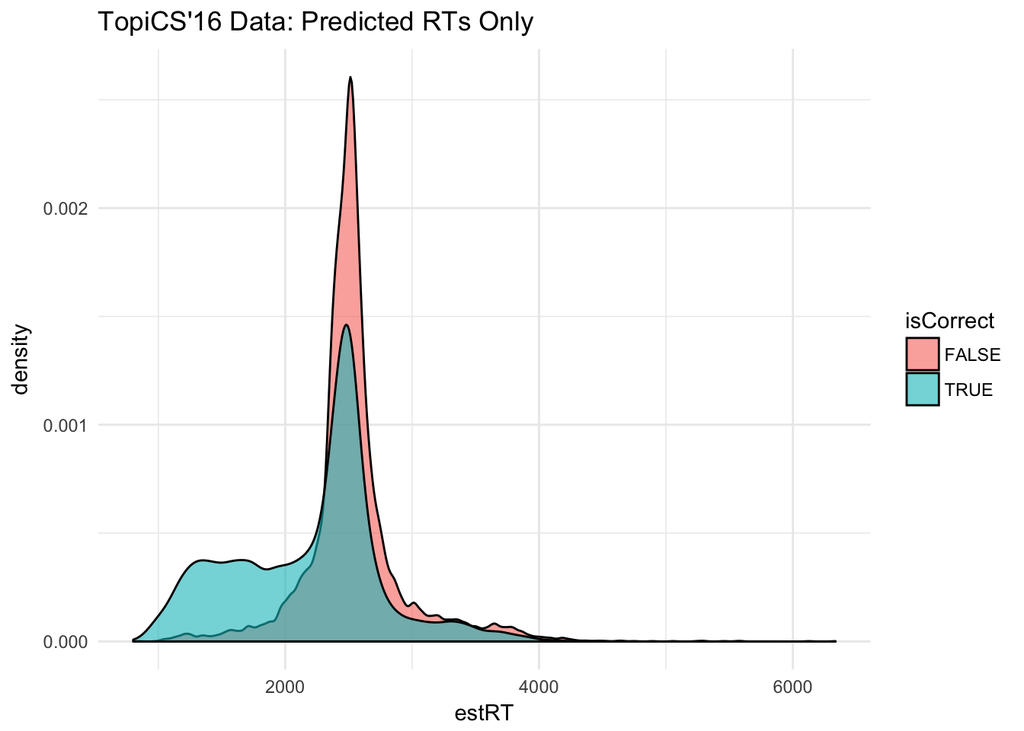

```r
ggplot(lab.data.RTsub, aes(estRT)) + geom_density(aes(fill=isCorrect), alpha=.6) + labs(title="TopiCS'16 Data: Predicted RTs Only")
```